# Multiclass classification with Human Activity Recognition (HAR) data

May 24, 2015

### Introduction

The project’s site is at http://groupware.les.inf.puc-rio.br/har

The task is to apply a proper machine algorithm on a training subset of the data, verify its classification accuracy using the out of sample data set, and also produce predictions for 20 new records.

### Data

The data were downloaded from the links given by the course staff:

https://d396qusza40orc.cloudfront.net/predmachlearn/pml-training.csv (main data set)

https://d396qusza40orc.cloudfront.net/predmachlearn/pml-testing.csv (20 new cases)

The detailed information for the variables was found in the researchers paper [1].

The target variable is named classe and has a balanced distribution. We do not need to perform any balancing pre-processing. The 5 classes (labelled A to E) correspond to sitting-down, standing-up, standing, walking, and sitting:

```r
table( df$classe )
```

```
##
##    A    B    C    D    E
## 5580 3797 3422 3216 3607
```

### Pre-processing

After reading the data into a data frame df (see Appendix - 1 *“Commands to read the dataset”*), the next step was to delete variables which have too many missing values. Function numMiss() is in Appendix - 2 *“Function to examine percentage of missing values”*. 100 variables were deleted.

```r
# find variables with too many missing values and delete them
delMis <- numMiss( df )$nm.perc > 0.9
sum( delMis )
```

```
## [1] 100
```

```r
df <- df[ , -which( delMis ) ]
```

```r
# correlations between numeric predictors
nums <- sapply( df, is.numeric )
corMat <- cor( df[ , nums ] )

# remove correlated variables
delCor <- findCorrelation(corMat, cutoff = .90, verbose = FALSE )
delCor
```

```
## [1] 13  4 12 11 22 49 34
```

```r
df <- df[ , -delCor ]
```

For reasons of convenience, in the remaining 52 variables, we put two character ones (user_name in position 1 and new_window in position 4) just before the last variable classe which is the target.

```r
# re-arrange some columns: two character variables before class
df <- df[ , c( 2:3, 5:51, 1, 4, 52 )]
```

Next, we initialized the random number generator to produce a repeatable sequence and partitioned the data into a 60% training set and a 40% testing one. The character variables (including the target) were defined as factors.

```r
set.seed( 1234 )

inT <- createDataPartition( df$classe, p = 0.6,
                           list = FALSE )

training <- df[ inT, ]
testing <- df[ -inT, ]

rm( df )

training <- within( training, {
  user_name <- as.factor( user_name  )
  new_window <- as.factor( new_window  )
  classe <- as.factor( classe  )
  }
)

testing <- within( testing, {
  user_name <- as.factor( user_name  )
  new_window <- as.factor( new_window  )
  classe <- as.factor( classe  )
  }
)
```

Although not strictly necessary (because we had decided to use decision trees after some tests) we proceeded with the common center and scale transformations of the numeric variables, using the preProcess() function in caret. The transformations in the testing set were exactly the ones applied in the training set.

```r
xTrans <- preProcess( training[ , 1:49 ],
                      method = c("center", "scale") )
tmp <- predict( xTrans, training[ , 1:49 ] )
training <- cbind( tmp, training[ , 50:52 ] )

tmp <- predict( xTrans, testing[ , 1:49 ] )
testing <- cbind( tmp, testing[ , 50:52 ] )

row.names( training )<- 1:nrow( training )
row.names( testing )<- 1:nrow( testing )
```

### Modeling

As it turned out, a single C5.0 tree was sufficient to achieve excellent accuracy. The full results are shown in Appendix 3 - *“C5.0 model - Detailed results”*. Because the number of predictors was still large, we set the algorithm to perform further feature selection with “winnowing”. To estimate the out of sample error, we also applied 25 bootstrap operations. As shown below, the accuracy is 99.9% in the training set and 99.7% in the testing set.

```r
## 25 bootstrap iterations
fitControl <- trainControl( method = "boot632",
                            number = 25 )

# do not show "some row.names duplicated" warnings
options( warn = -1 )

model1 <- train( classe  ~., method = "C5.0Tree",
                 data = training,
                 trControl = fitControl,
                 control = C5.0Control( winnow = TRUE ) )
options( warn = 0 )

save( model1, file = "model1.Rdata" )

load( file = "model1.Rdata" )

tab1 <- predict( model1, newdata = training )
confusionMatrix( tab1, training$classe,
                 dnn = c( "Predicted", "Actual" ) )
```

```
## Confusion Matrix and Statistics
##
##          Actual
## Predicted    A    B    C    D    E
##         A 3347    1    0    0    1
##         B    0 2276    1    0    0
##         C    0    2 2051    4    0
##         D    1    0    2 1926    1
##         E    0    0    0    0 2163
##
## Overall Statistics
##
##                Accuracy : 0.9989
##                  95% CI : (0.9981, 0.9994)
##     No Information Rate : 0.2843
##     P-Value [Acc > NIR] : < 2.2e-16
##
##                   Kappa : 0.9986
##  Mcnemar's Test P-Value : NA
##
## Statistics by Class:
##
##                      Class: A Class: B Class: C Class: D Class: E
## Sensitivity            0.9997   0.9987   0.9985   0.9979   0.9991
## Specificity            0.9998   0.9999   0.9994   0.9996   1.0000
## Pos Pred Value         0.9994   0.9996   0.9971   0.9979   1.0000
## Neg Pred Value         0.9999   0.9997   0.9997   0.9996   0.9998
## Prevalence             0.2843   0.1935   0.1744   0.1639   0.1838
## Detection Rate         0.2842   0.1933   0.1742   0.1636   0.1837
## Detection Prevalence   0.2844   0.1934   0.1747   0.1639   0.1837
## Balanced Accuracy      0.9997   0.9993   0.9990   0.9988   0.9995
```

```r
tab2 <- predict( model1, newdata = testing )
confusionMatrix( tab2, testing$classe,
                 dnn = c( "Predicted", "Actual" ) )
```

```
## Confusion Matrix and Statistics
##
##          Actual
## Predicted    A    B    C    D    E
##         A 2230    0    0    0    3
##         B    0 1512    1    0    0
##         C    0    6 1364    1    0
##         D    1    0    3 1284    3
##         E    1    0    0    1 1436
##
## Overall Statistics
##
##                Accuracy : 0.9975
##                  95% CI : (0.9961, 0.9984)
##     No Information Rate : 0.2845
##     P-Value [Acc > NIR] : < 2.2e-16
##
##                   Kappa : 0.9968
##  Mcnemar's Test P-Value : NA
##
## Statistics by Class:
##
##                      Class: A Class: B Class: C Class: D Class: E
## Sensitivity            0.9991   0.9960   0.9971   0.9984   0.9958
## Specificity            0.9995   0.9998   0.9989   0.9989   0.9997
## Pos Pred Value         0.9987   0.9993   0.9949   0.9946   0.9986
## Neg Pred Value         0.9996   0.9991   0.9994   0.9997   0.9991
## Prevalence             0.2845   0.1935   0.1744   0.1639   0.1838
## Detection Rate         0.2842   0.1927   0.1738   0.1637   0.1830
## Detection Prevalence   0.2846   0.1928   0.1747   0.1645   0.1833
## Balanced Accuracy      0.9993   0.9979   0.9980   0.9987   0.9978
```

### Out of sample error estimation and other results

As shown in previous sections, in order to obtain a reliable estimate of the out of sample error, we first performed a simple split (by partitioning the data set) and then applied bootstrap on the training set. That is, the testing set after the partitioning is actually a validation data set.

The 95% confidence interval for the accuracy is (0.9961, 0.9984). We expected this high out of sample accuracy. In initial tests without bootstrapping the results on the testing set were the same.

Pairwise ROC curves are not presented, because these practically show the perfect lines. The variable importance is shown below. The variable roll_belt has an importance of 100% and is the top level splitting variable.

```r
v <- varImp( model1 )
v
```

```
## C5.0Tree variable importance
##
##   only 20 most important variables shown (out of 55)
##
##                      Overall
## roll_belt             100.00
## pitch_forearm          91.49
## raw_timestamp_part_1   85.36
## num_window             83.69
## yaw_belt               77.37
## pitch_belt             65.68
## magnet_belt_z          58.48
## magnet_dumbbell_z      51.04
## user_namejeremy        38.20
## accel_belt_x           17.67
## roll_dumbbell          12.83
## pitch_arm              10.37
## gyros_arm_x             5.89
## yaw_dumbbell            5.49
## roll_forearm            4.96
## user_namecarlitos       2.94
## user_namepedro          0.70
## user_namecharles        0.31
## accel_forearm_x         0.19
## magnet_dumbbell_y       0.07
```

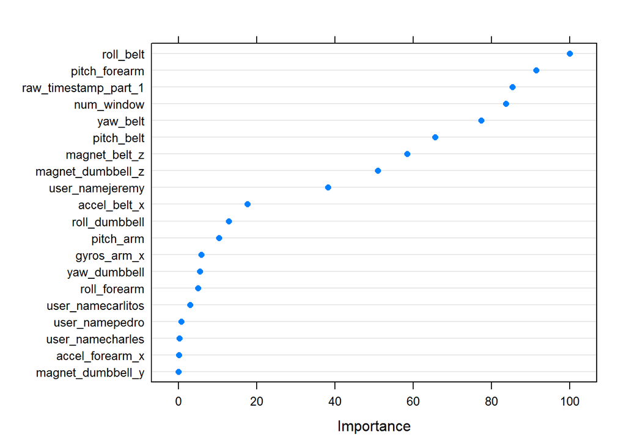

```r
dotPlot(  varImp( model1 ), top = 20 )
```

In the following, we create a variable to represent the top two levels of the tree in the model (see Appendix 3 - *“C5.0 model - Detailed results”*).

```r
testing <- within( testing, {
  treeVar <- ifelse( roll_belt > 1.043879 &
                       pitch_arm > 1.634051, 'Node 1',
             ifelse( roll_belt > 1.043879 &
                       pitch_arm <= 1.634051, 'Node 2',
             ifelse( roll_belt <= 1.043879 &
                       pitch_forearm > -1.623873, 'Node 3',
                     'Node 4' )))
  }
)
```

These nodes in the testing set are shown in the following bar chart. The differentiation is very clear. The node not shown has only 14 observations.

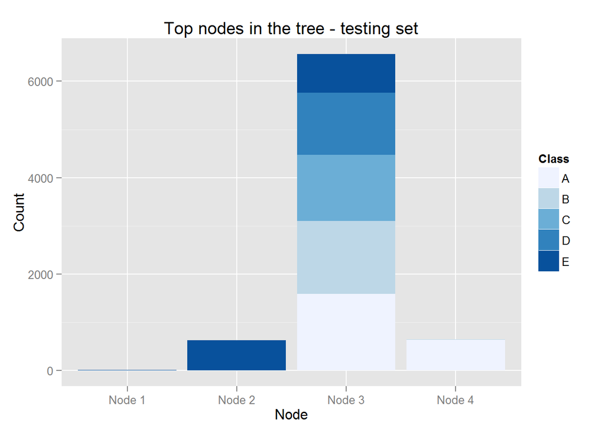

```r
ggplot( data = testing, aes( x = treeVar, fill =  classe) ) +
    geom_bar() + scale_fill_brewer( palette = 1 ) +
    labs( title = "Top nodes in the tree - testing set",
          y = "Count", x = "Node", fill = "Class")
```

### Prediction of new cases

The relevant code is shown below. The comments show the reproduction of the pre-processing steps. All cases were predicted correctly.

```r
# predicting classes of new cases

df.new <- read.table ( file = "pml-testing.csv", header = TRUE,
      sep = ",", quote = "\"'", stringsAsFactors = FALSE,
      dec = ".", row.names = NULL,
      na.strings = c( "NA", "#DIV/0!" ) )

df.new[ , 1 ] <- NULL

# leave same predictors in the same order
common_names <- intersect( names( training ), names( df.new ) )
df.new <- df.new[ , common_names ]

# center and scale using the transformation in the training set
tmp <- predict( xTrans, df.new[ , 1:49 ] )
df.new <- cbind( tmp, df.new[ , 50:51 ] )

tab3 <- predict( model1, newdata = df.new )

pml_write_files( tab3 )
```

### Conclusion:

In this assignment, we experimented with the C5.0 algorithm and the multiclass classification problem researched in a study involving Human Activity Recognition (HAR). The authors of the relevant paper used the C4.5 algorithm together with AdaBoost and achieved a weighted accuracy of 99.4% with much tuning.

The approach we tested here resulted to a better result with minimal effort. This confirms the authors conclusion on the power of decision trees in problems in this new area of investigation.

Finally, we used this model to predict the class of 20 new cases. The accuracy was 100% in these cases.

### References

[1] Ugulino, W.; Cardador, D.; Vega, K.; Velloso, E.; Milidiu, R.; Fuks, H. Wearable Computing: Accelerometers’ Data Classification of Body Postures and Movements. Proceedings of 21st Brazilian Symposium on Artificial Intelligence. Advances in Artificial Intelligence - SBIA 2012. In: Lecture Notes in Computer Science. , pp. 52-61. Curitiba, PR: Springer Berlin / Heidelberg, 2012. ISBN 978-3-642-34458-9. DOI: 10.1007/978-3-642-34459-6_6.

### Appendix

#### 1. Commands to read the dataset.

We labelled some divisions with zero to NAs and also deleted the first unnamed variable which contained a record index.

```r
df <- read.table ( file = "pml-training.csv", header = TRUE,
      sep = ",", quote = "\"'", stringsAsFactors = FALSE,
      dec = ".", row.names = NULL,
      na.strings = c( "NA", "#DIV/0!" ) )

df[ , 1 ] <- NULL
```

#### 2. Function to examine percentage of missing values.

```r
numMiss <- function( df ) {
# a function to return information on the missing values
# in a data frame
  nm <- vector( mode = "numeric", length = ncol( df ) )
  nm.perc <- vector( mode = "numeric", length = ncol( df ) )
  for( i in ( 1 : ncol( df ) ) ) {
    var <- names( df )[ i ]
    nm[ i ] <- sum( as.numeric( is.na( df[ , i ] ) ) )
    nm.perc[ i ] <- round( nm[ i ] / nrow( df ), 3 )
  }
  return( list( vars = names( df ), nm = nm, nm.perc = nm.perc ) )
}
```

#### 3. C5.0 model - Detailed results.

```r
summary( model1$finalModel )
```

```
##
## Call:
## C5.0.default(x = x, y = y, weights = wts, control = ..1)
##
##
## C5.0 [Release 2.07 GPL Edition]      Wed May 20 21:48:38 2015
## -------------------------------
##
## Class specified by attribute `outcome'
##
## Read 11776 cases (56 attributes) from undefined.data
##
## 27 attributes winnowed
## Estimated importance of remaining attributes:
##
##    2940%  raw_timestamp_part_1
##    1560%  num_window
##     881%  magnet_belt_z
##     621%  magnet_dumbbell_z
##     617%  roll_belt
##     483%  pitch_belt
##     296%  yaw_belt
##     198%  roll_dumbbell
##     147%  pitch_forearm
##     143%  user_namejeremy
##     126%  accel_dumbbell_z
##      57%  roll_forearm
##      36%  magnet_dumbbell_y
##      36%  user_namecarlitos
##      34%  user_namecharles
##      28%  accel_forearm_x
##      19%  user_namepedro
##       6%  pitch_arm
##       6%  accel_dumbbell_y
##       6%  magnet_dumbbell_x
##       4%  gyros_arm_x
##       4%  accel_dumbbell_x
##      <1%  accel_belt_x
##      <1%  accel_belt_y
##      <1%  magnet_belt_x
```

[output cut: 232 more lines]

```
##   38.20% user_namejeremy
##   17.67% accel_belt_x
##   12.83% roll_dumbbell
##   10.37% pitch_arm
##    5.89% gyros_arm_x
##    5.49% yaw_dumbbell
##    4.96% roll_forearm
##    2.94% user_namecarlitos
##    0.70% user_namepedro
##    0.31% user_namecharles
##    0.19% accel_forearm_x
##    0.07% magnet_dumbbell_y
##
##
## Time: 3.4 secs
```